# 3) Modeling

## Tehama County

```
Performing stepwise search to minimize aic
 ARIMA(1,2,1)(0,0,0)[0] intercept   : AIC=inf, Time=0.14 sec
 ARIMA(0,2,0)(0,0,0)[0] intercept   : AIC=596.915, Time=0.01 sec
 ARIMA(1,2,0)(0,0,0)[0] intercept   : AIC=567.628, Time=0.03 sec
 ARIMA(0,2,1)(0,0,0)[0] intercept   : AIC=inf, Time=0.09 sec
 ARIMA(0,2,0)(0,0,0)[0]             : AIC=594.944, Time=0.01 sec
 ARIMA(2,2,0)(0,0,0)[0] intercept   : AIC=554.762, Time=0.04 sec
 ARIMA(3,2,0)(0,0,0)[0] intercept   : AIC=547.391, Time=0.06 sec
 ARIMA(3,2,1)(0,0,0)[0] intercept   : AIC=543.793, Time=0.09 sec
 ARIMA(2,2,1)(0,0,0)[0] intercept   : AIC=inf, Time=0.18 sec
 ARIMA(3,2,2)(0,0,0)[0] intercept   : AIC=inf, Time=0.29 sec
 ARIMA(2,2,2)(0,0,0)[0] intercept   : AIC=inf, Time=0.17 sec
 ARIMA(3,2,1)(0,0,0)[0]             : AIC=542.016, Time=0.06 sec
 ARIMA(2,2,1)(0,0,0)[0]             : AIC=inf, Time=0.13 sec
 ARIMA(3,2,0)(0,0,0)[0]             : AIC=545.566, Time=0.03 sec
 ARIMA(3,2,2)(0,0,0)[0]             : AIC=inf, Time=0.25 sec
 ARIMA(2,2,0)(0,0,0)[0]             : AIC=552.906, Time=0.02 sec
 ARIMA(2,2,2)(0,0,0)[0]             : AIC=inf, Time=0.12 sec

Best model:  ARIMA(3,2,1)(0,0,0)[0]
Total fit time: 1.724 seconds
                               SARIMAX Results
==============================================================================
Dep. Variable:                      y   No. Observations:                   92
Model:               SARIMAX(3, 2, 1)   Log Likelihood                -266.008
Date:                Fri, 29 Jan 2021   AIC                            542.016
Time:                        17:43:02   BIC                            554.515
Sample:                             0   HQIC                           547.056
                                 - 92
Covariance Type:                  opg
==============================================================================
                 coef    std err          z      P>|z|      [0.025      0.975]
------------------------------------------------------------------------------
ar.L1         -0.4776      0.325     -1.472      0.141      -1.114       0.159
ar.L2         -0.3546      0.216     -1.638      0.101      -0.779       0.070
ar.L3         -0.1883      0.184     -1.024      0.306      -0.549       0.172
ma.L1         -0.5083      0.262     -1.937      0.053      -1.023       0.006
sigma2        21.3068      3.318      6.422      0.000      14.804      27.809
===================================================================================
Ljung-Box (L1) (Q):                   0.06   Jarque-Bera (JB):                 2.71
```

[output cut: 18 more lines]

```
----------------------------------------------------------------------------------------------------------
const                                      0.0570      0.121      0.471      0.638      -0.180       0.294
ar.L1.D2.7dayrollingavg_newlyconfirmed    -0.4783      0.204     -2.342      0.019      -0.879      -0.078
ar.L2.D2.7dayrollingavg_newlyconfirmed    -0.3548      0.185     -1.914      0.056      -0.718       0.009
ar.L3.D2.7dayrollingavg_newlyconfirmed    -0.1883      0.143     -1.313      0.189      -0.469       0.093
ma.L1.D2.7dayrollingavg_newlyconfirmed    -0.5090      0.194     -2.624      0.009      -0.889      -0.129
                                    Roots
=============================================================================
                  Real          Imaginary           Modulus         Frequency
-----------------------------------------------------------------------------
AR.1            0.0410           -1.6429j            1.6434           -0.2460
AR.2            0.0410           +1.6429j            1.6434            0.2460
AR.3           -1.9658           -0.0000j            1.9658           -0.5000
MA.1            1.9647           +0.0000j            1.9647            0.0000
-----------------------------------------------------------------------------
```

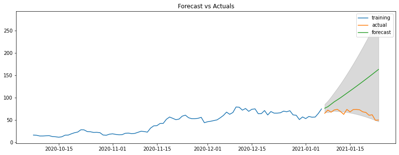

```
MSE of our forecast is: 3665.4470207701274
RMSE of our forecast is: 60.54293534980054
Performing stepwise search to minimize aic
 ARIMA(1,1,1)(0,0,0)[0] intercept   : AIC=653.938, Time=0.05 sec
 ARIMA(0,1,0)(0,0,0)[0] intercept   : AIC=654.595, Time=0.01 sec
 ARIMA(1,1,0)(0,0,0)[0] intercept   : AIC=652.013, Time=0.03 sec
 ARIMA(0,1,1)(0,0,0)[0] intercept   : AIC=652.508, Time=0.04 sec
 ARIMA(0,1,0)(0,0,0)[0]             : AIC=653.046, Time=0.01 sec
 ARIMA(2,1,0)(0,0,0)[0] intercept   : AIC=653.909, Time=0.04 sec
 ARIMA(2,1,1)(0,0,0)[0] intercept   : AIC=655.115, Time=0.10 sec
 ARIMA(1,1,0)(0,0,0)[0]             : AIC=650.691, Time=0.01 sec
 ARIMA(2,1,0)(0,0,0)[0]             : AIC=652.523, Time=0.02 sec
 ARIMA(1,1,1)(0,0,0)[0]             : AIC=652.574, Time=0.02 sec
 ARIMA(0,1,1)(0,0,0)[0]             : AIC=651.216, Time=0.02 sec
 ARIMA(2,1,1)(0,0,0)[0]             : AIC=653.454, Time=0.06 sec

Best model:  ARIMA(1,1,0)(0,0,0)[0]
Total fit time: 0.435 seconds
                               SARIMAX Results
==============================================================================
Dep. Variable:                      y   No. Observations:                  110
Model:               SARIMAX(1, 1, 0)   Log Likelihood                -323.346
Date:                Fri, 29 Jan 2021   AIC                            650.691
Time:                        17:43:03   BIC                            656.074
Sample:                             0   HQIC                           652.874
                                - 110
Covariance Type:                  opg
==============================================================================
                 coef    std err          z      P>|z|      [0.025      0.975]
------------------------------------------------------------------------------
ar.L1         -0.1970      0.093     -2.118      0.034      -0.379      -0.015
sigma2        22.0807      2.690      8.210      0.000      16.809      27.352
===================================================================================
Ljung-Box (L1) (Q):                   0.00   Jarque-Bera (JB):                 1.64
Prob(Q):                              0.99   Prob(JB):                         0.44
Heteroskedasticity (H):               6.74   Skew:                            -0.14
Prob(H) (two-sided):                  0.00   Kurtosis:                         3.54
===================================================================================

Warnings:
[1] Covariance matrix calculated using the outer product of gradients (complex-step).
```

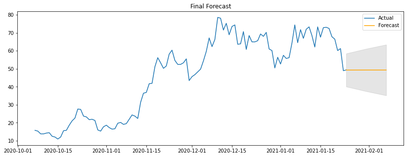

```
2021-01-24    49.300240
2021-01-31    49.317279
2021-02-07    49.313922
Freq: W-SUN, dtype: float64
```

```python
arima_model(Tehama)
```

## Riverside County

```
Performing stepwise search to minimize aic
 ARIMA(1,1,1)(0,0,0)[0] intercept   : AIC=563.188, Time=0.08 sec
 ARIMA(0,1,0)(0,0,0)[0] intercept   : AIC=581.413, Time=0.01 sec
 ARIMA(1,1,0)(0,0,0)[0] intercept   : AIC=561.905, Time=0.03 sec
 ARIMA(0,1,1)(0,0,0)[0] intercept   : AIC=564.721, Time=0.03 sec
 ARIMA(0,1,0)(0,0,0)[0]             : AIC=584.545, Time=0.01 sec
 ARIMA(2,1,0)(0,0,0)[0] intercept   : AIC=562.932, Time=0.05 sec
 ARIMA(2,1,1)(0,0,0)[0] intercept   : AIC=564.921, Time=0.07 sec
 ARIMA(1,1,0)(0,0,0)[0]             : AIC=561.854, Time=0.02 sec
 ARIMA(2,1,0)(0,0,0)[0]             : AIC=563.251, Time=0.03 sec
 ARIMA(1,1,1)(0,0,0)[0]             : AIC=563.352, Time=0.03 sec
 ARIMA(0,1,1)(0,0,0)[0]             : AIC=566.089, Time=0.02 sec
 ARIMA(2,1,1)(0,0,0)[0]             : AIC=565.251, Time=0.03 sec

Best model:  ARIMA(1,1,0)(0,0,0)[0]
Total fit time: 0.426 seconds
                               SARIMAX Results
==============================================================================
Dep. Variable:                      y   No. Observations:                   92
Model:               SARIMAX(1, 1, 0)   Log Likelihood                -278.927
Date:                Fri, 29 Jan 2021   AIC                            561.854
Time:                        17:43:04   BIC                            566.875
Sample:                             0   HQIC                           563.880
                                 - 92
Covariance Type:                  opg
==============================================================================
                 coef    std err          z      P>|z|      [0.025      0.975]
------------------------------------------------------------------------------
ar.L1          0.4864      0.069      7.084      0.000       0.352       0.621
sigma2        26.8271      2.167     12.381      0.000      22.580      31.074
===================================================================================
Ljung-Box (L1) (Q):                   0.07   Jarque-Bera (JB):               225.20
Prob(Q):                              0.80   Prob(JB):                         0.00
Heteroskedasticity (H):              56.29   Skew:                            -0.61
Prob(H) (two-sided):                  0.00   Kurtosis:                        10.61
===================================================================================

Warnings:
[1] Covariance matrix calculated using the outer product of gradients (complex-step).
                                    ARIMA Model Results
===========================================================================================
Dep. Variable:     D.7dayrollingavg_newlyconfirmed   No. Observations:                   91
Model:                              ARIMA(1, 1, 0)   Log Likelihood                -277.953
Method:                                    css-mle   S.D. of innovations              5.125
Date:                             Fri, 29 Jan 2021   AIC                            561.905
Time:                                     17:43:04   BIC                            569.438
Sample:                                 10-08-2020   HQIC                           564.944
                                      - 01-06-2021
=========================================================================================================
                                            coef    std err          z      P>|z|      [0.025      0.975]
---------------------------------------------------------------------------------------------------------
const                                     1.4125      0.981      1.440      0.150      -0.510       3.335
ar.L1.D.7dayrollingavg_newlyconfirmed     0.4571      0.092      4.943      0.000       0.276       0.638
                                    Roots
=============================================================================
                  Real          Imaginary           Modulus         Frequency
-----------------------------------------------------------------------------
AR.1            2.1877           +0.0000j            2.1877            0.0000
-----------------------------------------------------------------------------
```

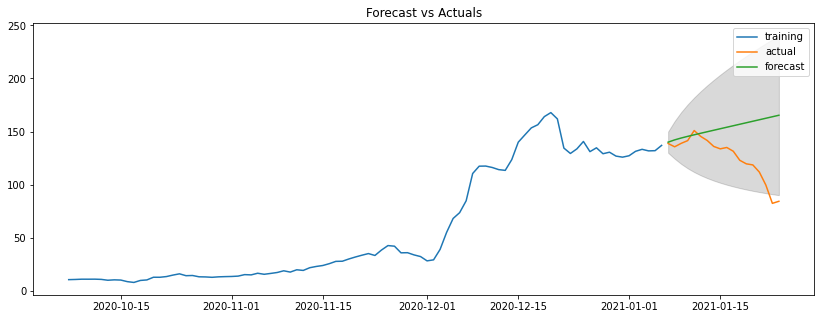

```
MSE of our forecast is: 1428.9228864949812
RMSE of our forecast is: 37.801096366309025
Performing stepwise search to minimize aic
 ARIMA(1,1,1)(0,0,0)[0] intercept   : AIC=681.099, Time=0.05 sec
 ARIMA(0,1,0)(0,0,0)[0] intercept   : AIC=704.927, Time=0.01 sec
 ARIMA(1,1,0)(0,0,0)[0] intercept   : AIC=679.688, Time=0.03 sec
 ARIMA(0,1,1)(0,0,0)[0] intercept   : AIC=683.758, Time=0.03 sec
 ARIMA(0,1,0)(0,0,0)[0]             : AIC=704.297, Time=0.01 sec
 ARIMA(2,1,0)(0,0,0)[0] intercept   : AIC=680.932, Time=0.05 sec
 ARIMA(2,1,1)(0,0,0)[0] intercept   : AIC=682.930, Time=0.08 sec
 ARIMA(1,1,0)(0,0,0)[0]             : AIC=678.200, Time=0.02 sec
 ARIMA(2,1,0)(0,0,0)[0]             : AIC=679.573, Time=0.02 sec
 ARIMA(1,1,1)(0,0,0)[0]             : AIC=679.689, Time=0.03 sec
 ARIMA(0,1,1)(0,0,0)[0]             : AIC=682.697, Time=0.02 sec
 ARIMA(2,1,1)(0,0,0)[0]             : AIC=681.573, Time=0.04 sec

Best model:  ARIMA(1,1,0)(0,0,0)[0]
Total fit time: 0.395 seconds
                               SARIMAX Results
==============================================================================
Dep. Variable:                      y   No. Observations:                  110
Model:               SARIMAX(1, 1, 0)   Log Likelihood                -337.100
Date:                Fri, 29 Jan 2021   AIC                            678.200
Time:                        17:43:04   BIC                            683.583
Sample:                             0   HQIC                           680.383
                                - 110
Covariance Type:                  opg
==============================================================================
                 coef    std err          z      P>|z|      [0.025      0.975]
------------------------------------------------------------------------------
ar.L1          0.4745      0.061      7.716      0.000       0.354       0.595
sigma2        28.3635      2.259     12.558      0.000      23.937      32.790
===================================================================================
Ljung-Box (L1) (Q):                   0.14   Jarque-Bera (JB):               132.89
Prob(Q):                              0.71   Prob(JB):                         0.00
Heteroskedasticity (H):              35.46   Skew:                            -0.47
Prob(H) (two-sided):                  0.00   Kurtosis:                         8.33
===================================================================================

Warnings:
[1] Covariance matrix calculated using the outer product of gradients (complex-step).
```

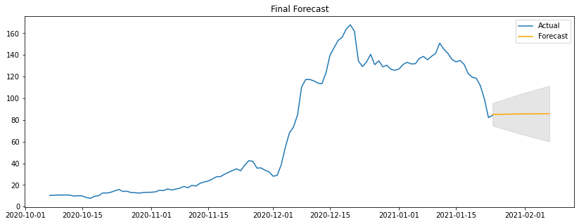

```
2021-01-24    85.122324
2021-01-31    85.561050
2021-02-07    85.769222
Freq: W-SUN, dtype: float64
```

```python
## Riverside County

arima_model(Riverside)
```

## Colusa County

```
Performing stepwise search to minimize aic
 ARIMA(1,1,1)(0,0,0)[0] intercept   : AIC=637.091, Time=0.07 sec
 ARIMA(0,1,0)(0,0,0)[0] intercept   : AIC=635.615, Time=0.01 sec
 ARIMA(1,1,0)(0,0,0)[0] intercept   : AIC=637.548, Time=0.02 sec
 ARIMA(0,1,1)(0,0,0)[0] intercept   : AIC=637.493, Time=0.04 sec
 ARIMA(0,1,0)(0,0,0)[0]             : AIC=634.508, Time=0.01 sec

Best model:  ARIMA(0,1,0)(0,0,0)[0]
Total fit time: 0.158 seconds
                               SARIMAX Results
==============================================================================
Dep. Variable:                      y   No. Observations:                   92
Model:               SARIMAX(0, 1, 0)   Log Likelihood                -316.254
Date:                Fri, 29 Jan 2021   AIC                            634.508
Time:                        17:43:05   BIC                            637.019
Sample:                             0   HQIC                           635.521
                                 - 92
Covariance Type:                  opg
==============================================================================
                 coef    std err          z      P>|z|      [0.025      0.975]
------------------------------------------------------------------------------
sigma2        61.1152      3.985     15.337      0.000      53.305      68.925
===================================================================================
Ljung-Box (L1) (Q):                   0.07   Jarque-Bera (JB):               314.85
Prob(Q):                              0.79   Prob(JB):                         0.00
Heteroskedasticity (H):              44.51   Skew:                            -0.99
Prob(H) (two-sided):                  0.00   Kurtosis:                        11.90
===================================================================================

Warnings:
[1] Covariance matrix calculated using the outer product of gradients (complex-step).
                                    ARIMA Model Results
===========================================================================================
Dep. Variable:     D.7dayrollingavg_newlyconfirmed   No. Observations:                   91
Model:                              ARIMA(0, 1, 0)   Log Likelihood                -315.808
Method:                                        css   S.D. of innovations              7.779
Date:                             Fri, 29 Jan 2021   AIC                            635.615
Time:                                     17:43:05   BIC                            640.637
Sample:                                 10-08-2020   HQIC                           637.641
                                      - 01-06-2021
==============================================================================
                 coef    std err          z      P>|z|      [0.025      0.975]
------------------------------------------------------------------------------
const          0.7723      0.815      0.947      0.344      -0.826       2.371
==============================================================================
```

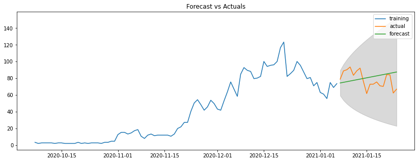

```
MSE of our forecast is: 165.25195474667112
RMSE of our forecast is: 12.855036162791263
Performing stepwise search to minimize aic
 ARIMA(1,1,1)(0,0,0)[0] intercept   : AIC=769.384, Time=0.06 sec
 ARIMA(0,1,0)(0,0,0)[0] intercept   : AIC=768.846, Time=0.01 sec
 ARIMA(1,1,0)(0,0,0)[0] intercept   : AIC=770.750, Time=0.03 sec
 ARIMA(0,1,1)(0,0,0)[0] intercept   : AIC=770.645, Time=0.04 sec
 ARIMA(0,1,0)(0,0,0)[0]             : AIC=767.414, Time=0.01 sec

Best model:  ARIMA(0,1,0)(0,0,0)[0]
Total fit time: 0.155 seconds
                               SARIMAX Results
==============================================================================
Dep. Variable:                      y   No. Observations:                  110
Model:               SARIMAX(0, 1, 0)   Log Likelihood                -382.707
Date:                Fri, 29 Jan 2021   AIC                            767.414
Time:                        17:43:05   BIC                            770.105
Sample:                             0   HQIC                           768.505
                                - 110
Covariance Type:                  opg
==============================================================================
                 coef    std err          z      P>|z|      [0.025      0.975]
------------------------------------------------------------------------------
sigma2        65.6456      4.422     14.846      0.000      56.979      74.312
===================================================================================
Ljung-Box (L1) (Q):                   0.10   Jarque-Bera (JB):               204.30
Prob(Q):                              0.75   Prob(JB):                         0.00
Heteroskedasticity (H):              24.38   Skew:                            -0.96
Prob(H) (two-sided):                  0.00   Kurtosis:                         9.43
===================================================================================

Warnings:
[1] Covariance matrix calculated using the outer product of gradients (complex-step).
```

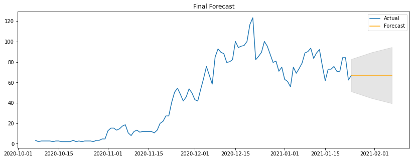

```
2021-01-24    66.96325
2021-01-31    66.96325
2021-02-07    66.96325
Freq: W-SUN, dtype: float64
```

```python
## Colusa County

arima_model(Colusa)
```

## Merced County

```
Performing stepwise search to minimize aic
 ARIMA(1,2,1)(0,0,0)[0] intercept   : AIC=inf, Time=0.15 sec
 ARIMA(0,2,0)(0,0,0)[0] intercept   : AIC=558.921, Time=0.01 sec
 ARIMA(1,2,0)(0,0,0)[0] intercept   : AIC=530.665, Time=0.02 sec
 ARIMA(0,2,1)(0,0,0)[0] intercept   : AIC=inf, Time=0.08 sec
 ARIMA(0,2,0)(0,0,0)[0]             : AIC=556.940, Time=0.01 sec
 ARIMA(2,2,0)(0,0,0)[0] intercept   : AIC=531.169, Time=0.04 sec
 ARIMA(2,2,1)(0,0,0)[0] intercept   : AIC=inf, Time=0.24 sec
 ARIMA(1,2,0)(0,0,0)[0]             : AIC=528.698, Time=0.01 sec
 ARIMA(2,2,0)(0,0,0)[0]             : AIC=529.206, Time=0.02 sec
 ARIMA(1,2,1)(0,0,0)[0]             : AIC=inf, Time=0.08 sec
 ARIMA(0,2,1)(0,0,0)[0]             : AIC=515.151, Time=0.03 sec
 ARIMA(0,2,2)(0,0,0)[0]             : AIC=inf, Time=0.07 sec
 ARIMA(1,2,2)(0,0,0)[0]             : AIC=510.706, Time=0.07 sec
 ARIMA(2,2,2)(0,0,0)[0]             : AIC=inf, Time=0.16 sec
 ARIMA(1,2,3)(0,0,0)[0]             : AIC=inf, Time=0.22 sec
 ARIMA(0,2,3)(0,0,0)[0]             : AIC=inf, Time=0.13 sec
 ARIMA(2,2,1)(0,0,0)[0]             : AIC=inf, Time=0.18 sec
 ARIMA(2,2,3)(0,0,0)[0]             : AIC=inf, Time=0.29 sec
 ARIMA(1,2,2)(0,0,0)[0] intercept   : AIC=512.639, Time=0.09 sec

Best model:  ARIMA(1,2,2)(0,0,0)[0]
Total fit time: 1.917 seconds
                               SARIMAX Results
==============================================================================
Dep. Variable:                      y   No. Observations:                   92
Model:               SARIMAX(1, 2, 2)   Log Likelihood                -251.353
Date:                Fri, 29 Jan 2021   AIC                            510.706
Time:                        17:43:07   BIC                            520.705
Sample:                             0   HQIC                           514.738
                                 - 92
Covariance Type:                  opg
==============================================================================
                 coef    std err          z      P>|z|      [0.025      0.975]
------------------------------------------------------------------------------
ar.L1         -0.9857      0.051    -19.470      0.000      -1.085      -0.886
ma.L1          0.1689      0.094      1.789      0.074      -0.016       0.354
ma.L2         -0.7044      0.105     -6.734      0.000      -0.909      -0.499
sigma2        15.3459      1.557      9.853      0.000      12.293      18.398
===================================================================================
```

[output cut: 17 more lines]

```
==========================================================================================================
                                             coef    std err          z      P>|z|      [0.025      0.975]
----------------------------------------------------------------------------------------------------------
const                                      0.0085        nan        nan        nan         nan         nan
ar.L1.D2.7dayrollingavg_newlyconfirmed    -1.0000        nan        nan        nan         nan         nan
ma.L1.D2.7dayrollingavg_newlyconfirmed    -0.0321      0.097     -0.333      0.739      -0.221       0.157
ma.L2.D2.7dayrollingavg_newlyconfirmed    -0.9679      0.094    -10.328      0.000      -1.152      -0.784
                                    Roots
=============================================================================
                  Real          Imaginary           Modulus         Frequency
-----------------------------------------------------------------------------
AR.1           -1.0000           +0.0000j            1.0000            0.5000
MA.1            1.0000           +0.0000j            1.0000            0.0000
MA.2           -1.0332           +0.0000j            1.0332            0.5000
-----------------------------------------------------------------------------
```

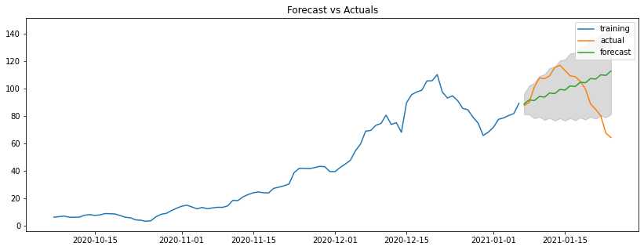

```
MSE of our forecast is: 414.19908659789894
RMSE of our forecast is: 20.35188164759954
Performing stepwise search to minimize aic
 ARIMA(1,2,1)(0,0,0)[0] intercept   : AIC=629.203, Time=0.06 sec
 ARIMA(0,2,0)(0,0,0)[0] intercept   : AIC=672.651, Time=0.01 sec
 ARIMA(1,2,0)(0,0,0)[0] intercept   : AIC=644.454, Time=0.03 sec
 ARIMA(0,2,1)(0,0,0)[0] intercept   : AIC=627.248, Time=0.03 sec
 ARIMA(0,2,0)(0,0,0)[0]             : AIC=670.655, Time=0.01 sec
 ARIMA(0,2,2)(0,0,0)[0] intercept   : AIC=629.204, Time=0.05 sec
 ARIMA(1,2,2)(0,0,0)[0] intercept   : AIC=623.932, Time=0.10 sec
 ARIMA(2,2,2)(0,0,0)[0] intercept   : AIC=inf, Time=0.33 sec
 ARIMA(1,2,3)(0,0,0)[0] intercept   : AIC=622.200, Time=0.13 sec
 ARIMA(0,2,3)(0,0,0)[0] intercept   : AIC=631.199, Time=0.07 sec
 ARIMA(2,2,3)(0,0,0)[0] intercept   : AIC=616.204, Time=0.22 sec
 ARIMA(3,2,3)(0,0,0)[0] intercept   : AIC=621.181, Time=0.21 sec
 ARIMA(3,2,2)(0,0,0)[0] intercept   : AIC=620.843, Time=0.13 sec
 ARIMA(2,2,3)(0,0,0)[0]             : AIC=614.441, Time=0.18 sec
 ARIMA(1,2,3)(0,0,0)[0]             : AIC=620.531, Time=0.09 sec
 ARIMA(2,2,2)(0,0,0)[0]             : AIC=621.766, Time=0.09 sec
 ARIMA(3,2,3)(0,0,0)[0]             : AIC=619.251, Time=0.18 sec
 ARIMA(1,2,2)(0,0,0)[0]             : AIC=622.167, Time=0.06 sec
 ARIMA(3,2,2)(0,0,0)[0]             : AIC=618.995, Time=0.08 sec

Best model:  ARIMA(2,2,3)(0,0,0)[0]
Total fit time: 2.074 seconds
                               SARIMAX Results
==============================================================================
Dep. Variable:                      y   No. Observations:                  110
Model:               SARIMAX(2, 2, 3)   Log Likelihood                -301.221
Date:                Fri, 29 Jan 2021   AIC                            614.441
Time:                        17:43:10   BIC                            630.534
Sample:                             0   HQIC                           620.966
                                - 110
Covariance Type:                  opg
==============================================================================
                 coef    std err          z      P>|z|      [0.025      0.975]
------------------------------------------------------------------------------
ar.L1         -1.4544      0.123    -11.791      0.000      -1.696      -1.213
ar.L2         -0.5738      0.131     -4.384      0.000      -0.830      -0.317
ma.L1          0.9417      0.109      8.630      0.000       0.728       1.156
ma.L2         -0.4469      0.106     -4.201      0.000      -0.655      -0.238
ma.L3         -0.7491      0.072    -10.474      0.000      -0.889      -0.609
sigma2        15.0685      1.562      9.647      0.000      12.007      18.130
===================================================================================
Ljung-Box (L1) (Q):                   0.20   Jarque-Bera (JB):               200.18
Prob(Q):                              0.66   Prob(JB):                         0.00
Heteroskedasticity (H):              17.18   Skew:                             0.94
Prob(H) (two-sided):                  0.00   Kurtosis:                         9.40
===================================================================================

Warnings:
[1] Covariance matrix calculated using the outer product of gradients (complex-step).
```

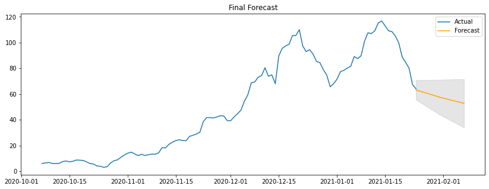

```
2021-01-24    63.227180
2021-01-31    57.500117
2021-02-07    52.784666
Freq: W-SUN, dtype: float64
```

```python
## Merced County## Merced County

arima_model(Merced)
```

## Santa Barbara County

```
Performing stepwise search to minimize aic
 ARIMA(1,2,1)(0,0,0)[0] intercept   : AIC=inf, Time=0.15 sec
 ARIMA(0,2,0)(0,0,0)[0] intercept   : AIC=468.053, Time=0.01 sec
 ARIMA(1,2,0)(0,0,0)[0] intercept   : AIC=415.870, Time=0.02 sec
 ARIMA(0,2,1)(0,0,0)[0] intercept   : AIC=inf, Time=0.11 sec
 ARIMA(0,2,0)(0,0,0)[0]             : AIC=466.084, Time=0.01 sec
 ARIMA(2,2,0)(0,0,0)[0] intercept   : AIC=397.520, Time=0.03 sec
 ARIMA(3,2,0)(0,0,0)[0] intercept   : AIC=391.290, Time=0.05 sec
 ARIMA(3,2,1)(0,0,0)[0] intercept   : AIC=387.236, Time=0.07 sec
 ARIMA(2,2,1)(0,0,0)[0] intercept   : AIC=385.448, Time=0.07 sec
 ARIMA(2,2,2)(0,0,0)[0] intercept   : AIC=387.307, Time=0.15 sec
 ARIMA(1,2,2)(0,0,0)[0] intercept   : AIC=385.307, Time=0.08 sec
 ARIMA(0,2,2)(0,0,0)[0] intercept   : AIC=383.646, Time=0.05 sec
 ARIMA(0,2,3)(0,0,0)[0] intercept   : AIC=385.289, Time=0.07 sec
 ARIMA(1,2,3)(0,0,0)[0] intercept   : AIC=inf, Time=0.35 sec
 ARIMA(0,2,2)(0,0,0)[0]             : AIC=382.768, Time=0.03 sec
 ARIMA(0,2,1)(0,0,0)[0]             : AIC=392.091, Time=0.03 sec
 ARIMA(1,2,2)(0,0,0)[0]             : AIC=384.519, Time=0.04 sec
 ARIMA(0,2,3)(0,0,0)[0]             : AIC=384.521, Time=0.04 sec
 ARIMA(1,2,1)(0,0,0)[0]             : AIC=383.493, Time=0.02 sec
 ARIMA(1,2,3)(0,0,0)[0]             : AIC=inf, Time=0.22 sec

Best model:  ARIMA(0,2,2)(0,0,0)[0]
Total fit time: 1.606 seconds
                               SARIMAX Results
==============================================================================
Dep. Variable:                      y   No. Observations:                   92
Model:               SARIMAX(0, 2, 2)   Log Likelihood                -188.384
Date:                Fri, 29 Jan 2021   AIC                            382.768
Time:                        17:43:12   BIC                            390.267
Sample:                             0   HQIC                           385.792
                                 - 92
Covariance Type:                  opg
==============================================================================
                 coef    std err          z      P>|z|      [0.025      0.975]
------------------------------------------------------------------------------
ma.L1         -1.1835      0.081    -14.665      0.000      -1.342      -1.025
ma.L2          0.4027      0.079      5.104      0.000       0.248       0.557
sigma2         3.7836      0.390      9.709      0.000       3.020       4.547
===================================================================================
```

[output cut: 15 more lines]

```
Sample:                                  10-09-2020   HQIC                           387.679
                                       - 01-06-2021
==========================================================================================================
                                             coef    std err          z      P>|z|      [0.025      0.975]
----------------------------------------------------------------------------------------------------------
const                                      0.0465      0.043      1.077      0.281      -0.038       0.131
ma.L1.D2.7dayrollingavg_newlyconfirmed    -1.1933      0.094    -12.696      0.000      -1.378      -1.009
ma.L2.D2.7dayrollingavg_newlyconfirmed     0.3991      0.098      4.083      0.000       0.208       0.591
                                    Roots
=============================================================================
                  Real          Imaginary           Modulus         Frequency
-----------------------------------------------------------------------------
MA.1            1.4950           -0.5202j            1.5829           -0.0533
MA.2            1.4950           +0.5202j            1.5829            0.0533
-----------------------------------------------------------------------------
```

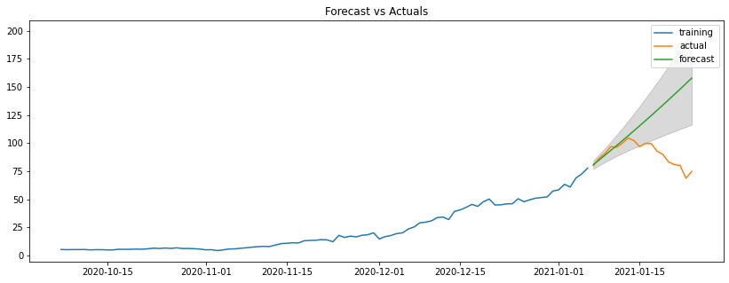

```
MSE of our forecast is: 1681.254716772578
RMSE of our forecast is: 41.003106184441414
Performing stepwise search to minimize aic
 ARIMA(1,2,1)(0,0,0)[0] intercept   : AIC=522.577, Time=0.06 sec
 ARIMA(0,2,0)(0,0,0)[0] intercept   : AIC=605.575, Time=0.01 sec
 ARIMA(1,2,0)(0,0,0)[0] intercept   : AIC=552.531, Time=0.02 sec
 ARIMA(0,2,1)(0,0,0)[0] intercept   : AIC=534.631, Time=0.04 sec
 ARIMA(0,2,0)(0,0,0)[0]             : AIC=603.598, Time=0.01 sec
 ARIMA(2,2,1)(0,0,0)[0] intercept   : AIC=519.406, Time=0.05 sec
 ARIMA(2,2,0)(0,0,0)[0] intercept   : AIC=527.126, Time=0.03 sec
 ARIMA(3,2,1)(0,0,0)[0] intercept   : AIC=519.648, Time=0.07 sec
 ARIMA(2,2,2)(0,0,0)[0] intercept   : AIC=515.341, Time=0.09 sec
 ARIMA(1,2,2)(0,0,0)[0] intercept   : AIC=514.728, Time=0.10 sec
 ARIMA(0,2,2)(0,0,0)[0] intercept   : AIC=512.848, Time=0.04 sec
 ARIMA(0,2,3)(0,0,0)[0] intercept   : AIC=514.677, Time=0.06 sec
 ARIMA(1,2,3)(0,0,0)[0] intercept   : AIC=515.725, Time=0.13 sec
 ARIMA(0,2,2)(0,0,0)[0]             : AIC=510.890, Time=0.02 sec
 ARIMA(0,2,1)(0,0,0)[0]             : AIC=532.750, Time=0.02 sec
 ARIMA(1,2,2)(0,0,0)[0]             : AIC=512.777, Time=0.09 sec
 ARIMA(0,2,3)(0,0,0)[0]             : AIC=512.730, Time=0.04 sec
 ARIMA(1,2,1)(0,0,0)[0]             : AIC=520.749, Time=0.03 sec
 ARIMA(1,2,3)(0,0,0)[0]             : AIC=513.778, Time=0.10 sec

Best model:  ARIMA(0,2,2)(0,0,0)[0]
Total fit time: 1.027 seconds
                               SARIMAX Results
==============================================================================
Dep. Variable:                      y   No. Observations:                  110
Model:               SARIMAX(0, 2, 2)   Log Likelihood                -252.445
Date:                Fri, 29 Jan 2021   AIC                            510.890
Time:                        17:43:14   BIC                            518.936
Sample:                             0   HQIC                           514.153
                                - 110
Covariance Type:                  opg
==============================================================================
                 coef    std err          z      P>|z|      [0.025      0.975]
------------------------------------------------------------------------------
ma.L1         -1.1742      0.081    -14.522      0.000      -1.333      -1.016
ma.L2          0.5692      0.070      8.082      0.000       0.431       0.707
sigma2         6.1853      0.601     10.294      0.000       5.008       7.363
===================================================================================
Ljung-Box (L1) (Q):                   0.12   Jarque-Bera (JB):                23.76
Prob(Q):                              0.73   Prob(JB):                         0.00
Heteroskedasticity (H):              69.68   Skew:                            -0.23
Prob(H) (two-sided):                  0.00   Kurtosis:                         5.25
===================================================================================

Warnings:
[1] Covariance matrix calculated using the outer product of gradients (complex-step).
```

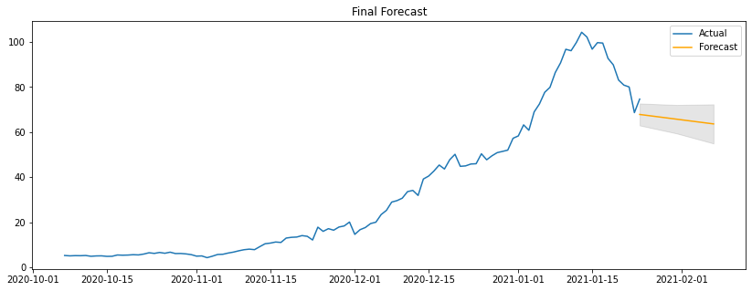

```
2021-01-24    67.848888
2021-01-31    65.751342
2021-02-07    63.653796
Freq: W-SUN, dtype: float64
```

```python
## Santa Barbara County## Santa Barbara County

arima_model(Santa_Barbara)
```

## Inyo County

```
Performing stepwise search to minimize aic
 ARIMA(1,1,1)(0,0,0)[0] intercept   : AIC=602.481, Time=0.05 sec
 ARIMA(0,1,0)(0,0,0)[0] intercept   : AIC=601.693, Time=0.01 sec
 ARIMA(1,1,0)(0,0,0)[0] intercept   : AIC=602.401, Time=0.03 sec
 ARIMA(0,1,1)(0,0,0)[0] intercept   : AIC=601.458, Time=0.04 sec
 ARIMA(0,1,0)(0,0,0)[0]             : AIC=600.089, Time=0.01 sec

Best model:  ARIMA(0,1,0)(0,0,0)[0]
Total fit time: 0.146 seconds
                               SARIMAX Results
==============================================================================
Dep. Variable:                      y   No. Observations:                   92
Model:               SARIMAX(0, 1, 0)   Log Likelihood                -299.044
Date:                Fri, 29 Jan 2021   AIC                            600.089
Time:                        17:43:14   BIC                            602.600
Sample:                             0   HQIC                           601.102
                                 - 92
Covariance Type:                  opg
==============================================================================
                 coef    std err          z      P>|z|      [0.025      0.975]
------------------------------------------------------------------------------
sigma2        41.8683      3.065     13.658      0.000      35.860      47.877
===================================================================================
Ljung-Box (L1) (Q):                   1.34   Jarque-Bera (JB):               179.24
Prob(Q):                              0.25   Prob(JB):                         0.00
Heteroskedasticity (H):              16.87   Skew:                            -1.07
Prob(H) (two-sided):                  0.00   Kurtosis:                         9.54
===================================================================================

Warnings:
[1] Covariance matrix calculated using the outer product of gradients (complex-step).
                                    ARIMA Model Results
===========================================================================================
Dep. Variable:     D.7dayrollingavg_newlyconfirmed   No. Observations:                   91
Model:                              ARIMA(0, 1, 0)   Log Likelihood                -298.846
Method:                                        css   S.D. of innovations              6.456
Date:                             Fri, 29 Jan 2021   AIC                            601.693
Time:                                     17:43:14   BIC                            606.714
Sample:                                 10-08-2020   HQIC                           603.719
                                      - 01-06-2021
==============================================================================
                 coef    std err          z      P>|z|      [0.025      0.975]
------------------------------------------------------------------------------
const          0.4264      0.677      0.630      0.529      -0.900       1.753
==============================================================================
```

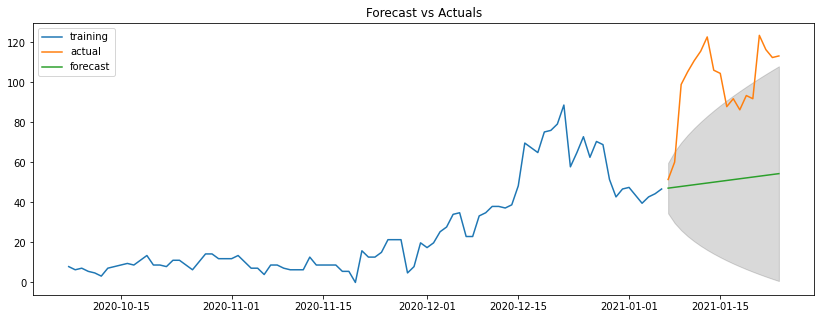

```
MSE of our forecast is: 2714.2434887620248
RMSE of our forecast is: 52.098401978966926
Performing stepwise search to minimize aic
 ARIMA(1,1,1)(0,0,0)[0] intercept   : AIC=773.685, Time=0.08 sec
 ARIMA(0,1,0)(0,0,0)[0] intercept   : AIC=769.830, Time=0.01 sec
 ARIMA(1,1,0)(0,0,0)[0] intercept   : AIC=771.685, Time=0.03 sec
 ARIMA(0,1,1)(0,0,0)[0] intercept   : AIC=771.685, Time=0.03 sec
 ARIMA(0,1,0)(0,0,0)[0]             : AIC=769.363, Time=0.01 sec

Best model:  ARIMA(0,1,0)(0,0,0)[0]
Total fit time: 0.161 seconds
                               SARIMAX Results
==============================================================================
Dep. Variable:                      y   No. Observations:                  110
Model:               SARIMAX(0, 1, 0)   Log Likelihood                -383.682
Date:                Fri, 29 Jan 2021   AIC                            769.363
Time:                        17:43:14   BIC                            772.055
Sample:                             0   HQIC                           770.455
                                - 110
Covariance Type:                  opg
==============================================================================
                 coef    std err          z      P>|z|      [0.025      0.975]
------------------------------------------------------------------------------
sigma2        66.8301      4.246     15.741      0.000      58.509      75.151
===================================================================================
Ljung-Box (L1) (Q):                   0.15   Jarque-Bera (JB):               229.10
Prob(Q):                              0.70   Prob(JB):                         0.00
Heteroskedasticity (H):              29.53   Skew:                             0.69
Prob(H) (two-sided):                  0.00   Kurtosis:                         9.97
===================================================================================

Warnings:
[1] Covariance matrix calculated using the outer product of gradients (complex-step).
```

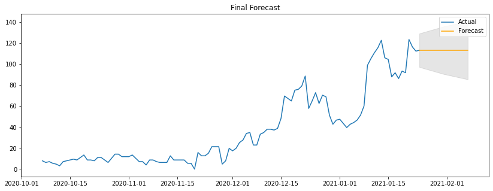

```
2021-01-24    113.246696
2021-01-31    113.246696
2021-02-07    113.246696
Freq: W-SUN, dtype: float64
```

```python
## Inyo County## Tulare County## Inyo County

arima_model(Inyo)
```

## Tulare County

```
Performing stepwise search to minimize aic
 ARIMA(1,2,1)(0,0,0)[0] intercept   : AIC=inf, Time=0.18 sec
 ARIMA(0,2,0)(0,0,0)[0] intercept   : AIC=556.066, Time=0.01 sec
 ARIMA(1,2,0)(0,0,0)[0] intercept   : AIC=551.819, Time=0.03 sec
 ARIMA(0,2,1)(0,0,0)[0] intercept   : AIC=523.460, Time=0.04 sec
 ARIMA(0,2,0)(0,0,0)[0]             : AIC=554.066, Time=0.01 sec
 ARIMA(0,2,2)(0,0,0)[0] intercept   : AIC=inf, Time=0.15 sec
 ARIMA(1,2,2)(0,0,0)[0] intercept   : AIC=inf, Time=0.14 sec
 ARIMA(0,2,1)(0,0,0)[0]             : AIC=521.514, Time=0.02 sec
 ARIMA(1,2,1)(0,0,0)[0]             : AIC=inf, Time=0.09 sec
 ARIMA(0,2,2)(0,0,0)[0]             : AIC=inf, Time=0.07 sec
 ARIMA(1,2,0)(0,0,0)[0]             : AIC=549.819, Time=0.01 sec
 ARIMA(1,2,2)(0,0,0)[0]             : AIC=inf, Time=0.11 sec

Best model:  ARIMA(0,2,1)(0,0,0)[0]
Total fit time: 0.875 seconds
                               SARIMAX Results
==============================================================================
Dep. Variable:                      y   No. Observations:                   92
Model:               SARIMAX(0, 2, 1)   Log Likelihood                -258.757
Date:                Fri, 29 Jan 2021   AIC                            521.514
Time:                        17:43:16   BIC                            526.513
Sample:                             0   HQIC                           523.530
                                 - 92
Covariance Type:                  opg
==============================================================================
                 coef    std err          z      P>|z|      [0.025      0.975]
------------------------------------------------------------------------------
ma.L1         -0.9102      0.043    -21.190      0.000      -0.994      -0.826
sigma2        18.0411      0.987     18.271      0.000      16.106      19.976
===================================================================================
Ljung-Box (L1) (Q):                   3.08   Jarque-Bera (JB):               911.76
Prob(Q):                              0.08   Prob(JB):                         0.00
Heteroskedasticity (H):              91.09   Skew:                            -2.27
Prob(H) (two-sided):                  0.00   Kurtosis:                        17.92
===================================================================================

Warnings:
[1] Covariance matrix calculated using the outer product of gradients (complex-step).
                                    ARIMA Model Results
============================================================================================
Dep. Variable:     D2.7dayrollingavg_newlyconfirmed   No. Observations:                   90
Model:                               ARIMA(0, 2, 1)   Log Likelihood                -258.752
Method:                                     css-mle   S.D. of innovations              4.183
Date:                              Fri, 29 Jan 2021   AIC                            523.504
Time:                                      17:43:16   BIC                            531.004
Sample:                                  10-09-2020   HQIC                           526.529
                                       - 01-06-2021
==========================================================================================================
                                             coef    std err          z      P>|z|      [0.025      0.975]
----------------------------------------------------------------------------------------------------------
const                                      0.0141      0.017      0.844      0.399      -0.019       0.047
ma.L1.D2.7dayrollingavg_newlyconfirmed    -1.0000      0.070    -14.304      0.000      -1.137      -0.863
                                    Roots
=============================================================================
                  Real          Imaginary           Modulus         Frequency
-----------------------------------------------------------------------------
MA.1            1.0000           +0.0000j            1.0000            0.0000
-----------------------------------------------------------------------------
```

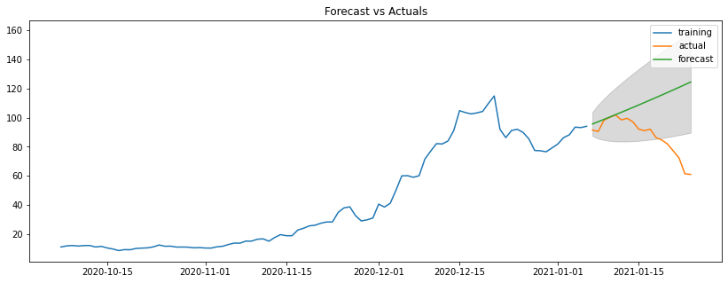

```
MSE of our forecast is: 894.2127089654495
RMSE of our forecast is: 29.903389589901835
Performing stepwise search to minimize aic
 ARIMA(1,2,1)(0,0,0)[0] intercept   : AIC=622.065, Time=0.07 sec
 ARIMA(0,2,0)(0,0,0)[0] intercept   : AIC=663.692, Time=0.01 sec
 ARIMA(1,2,0)(0,0,0)[0] intercept   : AIC=656.375, Time=0.02 sec
 ARIMA(0,2,1)(0,0,0)[0] intercept   : AIC=623.564, Time=0.04 sec
 ARIMA(0,2,0)(0,0,0)[0]             : AIC=661.693, Time=0.01 sec
 ARIMA(2,2,1)(0,0,0)[0] intercept   : AIC=inf, Time=0.07 sec
 ARIMA(1,2,2)(0,0,0)[0] intercept   : AIC=621.872, Time=0.10 sec
 ARIMA(0,2,2)(0,0,0)[0] intercept   : AIC=620.253, Time=0.06 sec
 ARIMA(0,2,3)(0,0,0)[0] intercept   : AIC=621.252, Time=0.09 sec
 ARIMA(1,2,3)(0,0,0)[0] intercept   : AIC=621.584, Time=0.15 sec
 ARIMA(0,2,2)(0,0,0)[0]             : AIC=618.544, Time=0.04 sec
 ARIMA(0,2,1)(0,0,0)[0]             : AIC=621.842, Time=0.02 sec
 ARIMA(1,2,2)(0,0,0)[0]             : AIC=620.161, Time=0.07 sec
 ARIMA(0,2,3)(0,0,0)[0]             : AIC=619.513, Time=0.05 sec
 ARIMA(1,2,1)(0,0,0)[0]             : AIC=620.366, Time=0.04 sec
 ARIMA(1,2,3)(0,0,0)[0]             : AIC=619.728, Time=0.09 sec

Best model:  ARIMA(0,2,2)(0,0,0)[0]
Total fit time: 0.934 seconds
                               SARIMAX Results
==============================================================================
Dep. Variable:                      y   No. Observations:                  110
Model:               SARIMAX(0, 2, 2)   Log Likelihood                -306.272
Date:                Fri, 29 Jan 2021   AIC                            618.544
Time:                        17:43:17   BIC                            626.591
Sample:                             0   HQIC                           621.807
                                - 110
Covariance Type:                  opg
==============================================================================
                 coef    std err          z      P>|z|      [0.025      0.975]
------------------------------------------------------------------------------
ma.L1         -0.6490      0.136     -4.758      0.000      -0.916      -0.382
ma.L2         -0.2626      0.159     -1.647      0.100      -0.575       0.050
sigma2        16.7551      0.971     17.254      0.000      14.852      18.658
===================================================================================
Ljung-Box (L1) (Q):                   0.10   Jarque-Bera (JB):               995.29
Prob(Q):                              0.76   Prob(JB):                         0.00
Heteroskedasticity (H):              38.99   Skew:                            -2.15
Prob(H) (two-sided):                  0.00   Kurtosis:                        17.24
===================================================================================

Warnings:
[1] Covariance matrix calculated using the outer product of gradients (complex-step).
```

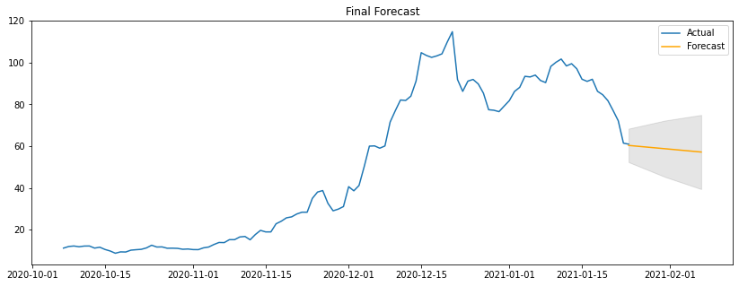

```
2021-01-24    60.375035
2021-01-31    58.793374
2021-02-07    57.211713
Freq: W-SUN, dtype: float64
```

```python
## Tulare County

arima_model(Tulare)
```

## SARIMA Model

```python
# SARIMAX modeling has been adapted from
# Thomas Vincent's "A Guide to Time Series Forecasting with ARIMA in Python"

warnings.filterwarnings("ignore")

# do "grid search" by automating the iteration
# to find the triplets of parameters with lowest AIC(Akaike Information Criterion) value
p = d = q = range(0, 2)
pdq = list(itertools.product(p, d, q))
seasonal_pdq = [(x[0], x[1], x[2], 12) for x in list(itertools.product(p, d, q))]

aic_d = {}
for param in pdq:

    for param_seasonal in seasonal_pdq:
        try:
            mod = sm.tsa.statespace.SARIMAX(y_train,
                                            order=param,
                                            seasonal_order=param_seasonal,
                                            enforce_stationarity=False,
                                            enforce_invertibility=False)
            results = mod.fit()
            aic_d[param, param_seasonal] = results.aic
        except:
            continue

# print out the parameters of the lowest AIC value
min(aic_d, key=aic_d.get)
```

```
((0, 1, 1), (0, 1, 1, 12))
```

- It seems the best parameter and seasonal parameters are (0,1,1)(0,1,1,12)
- now, we will build a model according t othat

```python
mod = sm.tsa.statespace.SARIMAX(y_train,
                                order=(0, 1, 1),
                                seasonal_order=(0, 1, 1, 12),
                                enforce_stationarity=False,
                                enforce_invertibility=False)

results = mod.fit()
results.summary()
```

SARIMAX Results

| Dep. Variable: | 7dayrollingavg_newlyconfirmed | No. Observations: | 92 |
| --- | --- | --- | --- |
| Model: | SARIMAX(0, 1, 1)x(0, 1, 1, 12) | Log Likelihood | -218.802 |
| Date: | Fri, 29 Jan 2021 | AIC | 443.603 |
| Time: | 17:43:24 | BIC | 450.126 |
| Sample: | 10-07-2020 | HQIC | 446.177 |
|  | - 01-06-2021 |  |  |
| Covariance Type: | opg |  |  |

|  | coef | std err | z | P>\|z\| | [0.025 | 0.975] |
| --- | --- | --- | --- | --- | --- | --- |
| ma.L1 | -0.1934 | 0.078 | -2.485 | 0.013 | -0.346 | -0.041 |
| ma.S.L12 | -0.7503 | 0.211 | -3.564 | 0.000 | -1.163 | -0.338 |
| sigma2 | 46.0411 | 5.410 | 8.510 | 0.000 | 35.437 | 56.645 |

| Ljung-Box (L1) (Q): | 0.06 | Jarque-Bera (JB): | 64.64 |
| --- | --- | --- | --- |
| Prob(Q): | 0.81 | Prob(JB): | 0.00 |
| Heteroskedasticity (H): | 29.78 | Skew: | -0.03 |
| Prob(H) (two-sided): | 0.00 | Kurtosis: | 7.88 |

Warnings:  
[1] Covariance matrix calculated using the outer product of gradients (complex-step).

- inspect the P>|z| value : ideally, they should be < 0.05 to be statistically significant, and they seem to be good
- now, check the plot diagnostics to inspect how the model looks

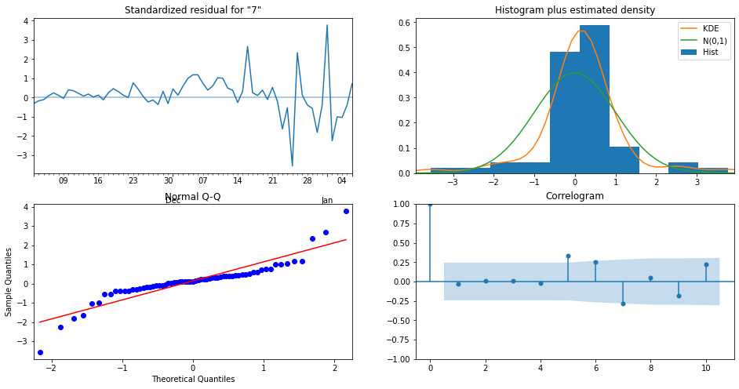

```python
plt_results = results.plot_diagnostics(figsize=(16, 8))
plt_results.show()
plt_results.savefig('../images/sarimax_diags.png')
```

### model validation using test data

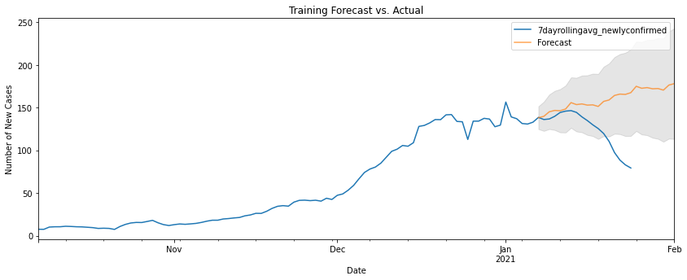

```python
# the train data stops at 2021-1-6,
# and now we use the test data that starts on 2021-1-7 to see how the model does compared to the actual data



pred = results.get_prediction(start=pd.to_datetime('2021-01-07'),
                              end=pd.to_datetime('2021-2-01'), dynamic=True)
pred_ci = pred.conf_int()

ax = y.plot(label='7dayrollingavg_newlyconfirmed')
pred.predicted_mean.plot(ax=ax, label='Forecast', alpha=.7, figsize=(14, 5))
ax.fill_between(pred_ci.index,
                pred_ci.iloc[:, 0],
                pred_ci.iloc[:, 1], color='k', alpha=.1)
ax.set_xlabel('Date')
ax.set_ylabel('Number of New Cases')

plt.title('Training Forecast vs. Actual')
plt.legend()
plt.savefig('../images/sarimax_la_county.png');
```

```python
y_forecasted = pred.predicted_mean
y_truth = (y['2021-1-7':])


diff = y_forecasted - y_truth['7dayrollingavg_newlyconfirmed']

mse = (diff ** 2).mean()
print('MSE of our forecasts is {}'.format(round(mse, 2)))

print('RMSE of our forecasts is {}'.format(round(np.sqrt(mse), 2)))
```

```
MSE of our forecasts is 1716.03
RMSE of our forecasts is 41.43
```

the model is not able to predict trend changes, so the difference between our forecast and the actual data widens as time goes on

however, unless we incorporate multiple factors that are used by actual forecasting models, such as:

> change in R-values, % infected, % recovered with immunity, county-by-county lockdown recommendations, and other demographics (age, race, ethnicity, income, employment)

forecasting the direction change is very difficult

### model using all data points

```python
# do "grid search" by automating the iteration
# to find the triplets of parameters with lowest AIC(Akaike Information Criterion) value
p = d = q = range(0, 2)
pdq = list(itertools.product(p, d, q))
seasonal_pdq = [(x[0], x[1], x[2], 12) for x in list(itertools.product(p, d, q))]

aic_d = {}
for param in pdq:

    for param_seasonal in seasonal_pdq:
        try:
            mod = sm.tsa.statespace.SARIMAX(y,
                                            order=param,
                                            seasonal_order=param_seasonal,
                                            enforce_stationarity=False,
                                            enforce_invertibility=False)
            results = mod.fit()
            aic_d[param, param_seasonal] = results.aic
        except:
            continue

# print out the parameters of the lowest AIC value
min(aic_d, key=aic_d.get)
```

```
((1, 1, 1), (0, 1, 1, 12))
```

- when using all data points up to date, best parameter and seasonal parameter change to (1,1,1)(0,1,1,12)
- now, we will build a model according to that

```python
mod = sm.tsa.statespace.SARIMAX(y,
                                order=(1, 1, 1),
                                seasonal_order=(0, 1, 1, 12),
                                enforce_stationarity=False,
                                enforce_invertibility=False)

results = mod.fit()

results.summary()
```

SARIMAX Results

| Dep. Variable: | 7dayrollingavg_newlyconfirmed | No. Observations: | 110 |
| --- | --- | --- | --- |
| Model: | SARIMAX(1, 1, 1)x(0, 1, 1, 12) | Log Likelihood | -277.466 |
| Date: | Fri, 29 Jan 2021 | AIC | 562.932 |
| Time: | 17:43:34 | BIC | 572.608 |
| Sample: | 10-07-2020 | HQIC | 566.819 |
|  | - 01-24-2021 |  |  |
| Covariance Type: | opg |  |  |

|  | coef | std err | z | P>\|z\| | [0.025 | 0.975] |
| --- | --- | --- | --- | --- | --- | --- |
| ar.L1 | 0.9646 | 0.080 | 12.071 | 0.000 | 0.808 | 1.121 |
| ma.L1 | -0.8553 | 0.074 | -11.555 | 0.000 | -1.000 | -0.710 |
| ma.S.L12 | -0.9999 | 470.012 | -0.002 | 0.998 | -922.207 | 920.207 |
| sigma2 | 37.7635 | 1.77e+04 | 0.002 | 0.998 | -3.47e+04 | 3.48e+04 |

| Ljung-Box (L1) (Q): | 2.30 | Jarque-Bera (JB): | 157.53 |
| --- | --- | --- | --- |
| Prob(Q): | 0.13 | Prob(JB): | 0.00 |
| Heteroskedasticity (H): | 22.39 | Skew: | 0.56 |
| Prob(H) (two-sided): | 0.00 | Kurtosis: | 9.66 |

Warnings:  
[1] Covariance matrix calculated using the outer product of gradients (complex-step).

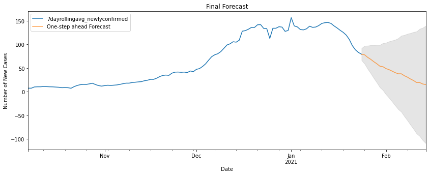

```python
pred = results.get_prediction(start=pd.to_datetime('2021-01-24'),
                              end=pd.to_datetime('2021-2-14'), dynamic=True)
pred_ci = pred.conf_int()
ax = y['2020':].plot(label='observed')
pred.predicted_mean.plot(ax=ax, label='One-step ahead Forecast', alpha=.7, figsize=(14, 5))
ax.fill_between(pred_ci.index,
                pred_ci.iloc[:, 0],
                pred_ci.iloc[:, 1], color='k', alpha=.1)
ax.set_xlabel('Date')
ax.set_ylabel('Number of New Cases')
plt.title('Final Forecast')
plt.legend()
plt.show()
```

```python
pred.predicted_mean
```

```
2021-01-24    79.224219
2021-01-25    77.981679
2021-01-26    72.709090
2021-01-27    68.513417
2021-01-28    63.521544
2021-01-29    59.132840
2021-01-30    53.965383
2021-01-31    52.918894
2021-02-01    48.909708
2021-02-02    46.647078
2021-02-03    43.568259
2021-02-04    40.357199
2021-02-05    37.940283
2021-02-06    37.939619
2021-02-07    33.864977
2021-02-08    30.824877
2021-02-09    26.947703
2021-02-10    23.634268
2021-02-11    19.504045
2021-02-12    19.458102
2021-02-13    16.414070
2021-02-14    15.082454
Freq: D, Name: predicted_mean, dtype: float64
```

- the downward trend has been incorporated for modeling when we used all data points
- with a fairly low confidence level, the uncertainty of predictions grow as time goes on

# Modeling for 7 Counties Highest New Cases/100k

```python
hotspot_counties = ['Tehama', 'Riverside', 'Colusa', 'Merced', 'Santa Barbara', 'Inyo', 'Tulare']
```

```python
features = ['hospitalized_covid_patients', '7dayrollingavg_newdeath', 'all_hospital_beds', 'icu_available_beds']
```

## Tehama County

```python
Tehama = county_df.loc['Tehama'].tail(110)
Riverside = county_df.loc['Riverside'].tail(110)
Colusa = county_df.loc['Colusa'].tail(110)
Merced = county_df.loc['Merced'].tail(110)
Santa_Barbara = county_df.loc['Santa Barbara'].tail(110)
Inyo = county_df.loc['Inyo'].tail(110)
Tulare = county_df.loc['Tulare'].tail(110)
```

```python
# build a function to incorporate everything
warnings.filterwarnings("ignore")
def sarimax_model (countydf):
    X = countydf[features]
    y = countydf[['7dayrollingavg_newlyconfirmed']]
    X_train = X.iloc[:92]
    X_test = X.iloc[92:]
    y_train = y.iloc[:92]
    y_test = y.iloc[92:]


    p = d = q = range(0, 2)
    pdq = list(itertools.product(p, d, q))
    seasonal_pdq = [(x[0], x[1], x[2], 12) for x in list(itertools.product(p, d, q))]

    aic_d = {}
    for param in pdq:

        for param_seasonal in seasonal_pdq:
            try:
                mod = sm.tsa.statespace.SARIMAX(y_train,
                                            order=param,
                                            seasonal_order=param_seasonal,
                                            enforce_stationarity=False,
                                            enforce_invertibility=False)
                results = mod.fit()
                aic_d[param, param_seasonal] = results.aic
            except:
                continue

    # print out the parameters of the lowest AIC value
    min_aic_params = min(aic_d, key=aic_d.get)
    min_order=min_aic_params[0]
    min_seasonal_order=min_aic_params[1]

    mod = sm.tsa.statespace.SARIMAX(y_train,
                                order=min_order,
                                seasonal_order=min_seasonal_order,
                                enforce_stationarity=False,
                                enforce_invertibility=False)

    results = mod.fit()
    print(results.summary())

    pred = results.get_prediction(start=pd.to_datetime('2021-01-07'),
                              end=pd.to_datetime('2021-2-01'), dynamic=True)
    pred_ci = pred.conf_int()

    ax = y.plot(label='7dayrollingavg_newlyconfirmed')
    pred.predicted_mean.plot(ax=ax, label='Train Forecast', alpha=.7, figsize=(14, 5))
    ax.fill_between(pred_ci.index,
                    pred_ci.iloc[:, 0],
                    pred_ci.iloc[:, 1], color='k', alpha=.1)
    ax.set_xlabel('Date')
    ax.set_ylabel('Number of New Cases')
    plt.title('Training Forecast vs. Actual')
    plt.legend()
    plt.show()

    y_forecasted = pred.predicted_mean
    y_truth = (y['2021-1-7':])


    diff = y_forecasted - y_truth['7dayrollingavg_newlyconfirmed']

    mse = (diff ** 2).mean()
    print('MSE of our forecasts is {}'.format(round(mse, 2)))

    print('RMSE of our forecasts is {}'.format(round(np.sqrt(mse), 2)))


    p = d = q = range(0, 2)
    pdq = list(itertools.product(p, d, q))
    seasonal_pdq = [(x[0], x[1], x[2], 12) for x in list(itertools.product(p, d, q))]

    aic_d = {}
    for param in pdq:

        for param_seasonal in seasonal_pdq:
            try:
                mod = sm.tsa.statespace.SARIMAX(y,
                                                order=param,
                                                seasonal_order=param_seasonal,
                                                enforce_stationarity=False,
                                                enforce_invertibility=False)
                results = mod.fit()
                aic_d[param, param_seasonal] = results.aic
            except:
                continue

    # print out the parameters of the lowest AIC value
    min_aic_params = min(aic_d, key=aic_d.get)
    min_order=min_aic_params[0]
    min_seasonal_order=min_aic_params[1]
    mod = sm.tsa.statespace.SARIMAX(y,
                                order=min_order,
                                seasonal_order=min_seasonal_order,
                                enforce_stationarity=False,
                                enforce_invertibility=False)

    results = mod.fit()

    print(results.summary())

    pred = results.get_prediction(start=pd.to_datetime('2021-01-24'),
                              end=pd.to_datetime('2021-2-14'), dynamic=True)
    pred_ci = pred.conf_int()
    ax = y['2020':].plot(label='observed')
    pred.predicted_mean.plot(ax=ax, label='Forecast of the next 21 days', alpha=.7, figsize=(14, 5))
    ax.fill_between(pred_ci.index,
                    pred_ci.iloc[:, 0],
                    pred_ci.iloc[:, 1], color='k', alpha=.1)
    ax.set_xlabel('Date')
    ax.set_ylabel('Number of New Cases')
    plt.title('Final Forecast')
    plt.legend()
    plt.show()
    print(pred.predicted_mean)
    return
```

```
                                     SARIMAX Results
==========================================================================================
Dep. Variable:      7dayrollingavg_newlyconfirmed   No. Observations:                   92
Model:             SARIMAX(0, 1, 1)x(0, 1, 1, 12)   Log Likelihood                -201.152
Date:                            Fri, 29 Jan 2021   AIC                            408.303
Time:                                    17:43:41   BIC                            414.827
Sample:                                10-07-2020   HQIC                           410.877
                                     - 01-06-2021
Covariance Type:                              opg
==============================================================================
                 coef    std err          z      P>|z|      [0.025      0.975]
------------------------------------------------------------------------------
ma.L1         -0.0346      0.176     -0.196      0.844      -0.380       0.311
ma.S.L12      -1.0001    563.596     -0.002      0.999   -1105.628    1103.628
sigma2        22.5095   1.27e+04      0.002      0.999   -2.48e+04    2.49e+04
===================================================================================
Ljung-Box (L1) (Q):                   0.00   Jarque-Bera (JB):                 4.31
Prob(Q):                              0.99   Prob(JB):                         0.12
Heteroskedasticity (H):               2.39   Skew:                            -0.58
Prob(H) (two-sided):                  0.05   Kurtosis:                         3.48
===================================================================================

Warnings:
[1] Covariance matrix calculated using the outer product of gradients (complex-step).
```

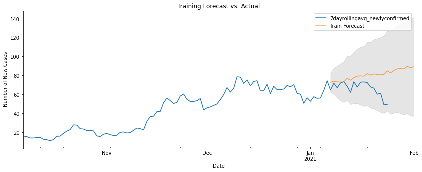

```
MSE of our forecasts is 229.8
RMSE of our forecasts is 15.16
                                     SARIMAX Results
==========================================================================================
Dep. Variable:      7dayrollingavg_newlyconfirmed   No. Observations:                  110
Model:             SARIMAX(1, 1, 1)x(0, 1, 1, 12)   Log Likelihood                -255.910
Date:                            Fri, 29 Jan 2021   AIC                            519.821
Time:                                    17:43:48   BIC                            529.496
Sample:                                10-07-2020   HQIC                           523.708
                                     - 01-24-2021
Covariance Type:                              opg
==============================================================================
                 coef    std err          z      P>|z|      [0.025      0.975]
------------------------------------------------------------------------------
ar.L1         -0.9977      0.051    -19.394      0.000      -1.099      -0.897
ma.L1          1.0000   1157.000      0.001      0.999   -2266.678    2268.678
ma.S.L12      -1.0000   2731.489     -0.000      1.000   -5354.621    5352.621
sigma2        21.4669   5.28e+04      0.000      1.000   -1.04e+05    1.04e+05
===================================================================================
Ljung-Box (L1) (Q):                   0.01   Jarque-Bera (JB):                 2.05
Prob(Q):                              0.93   Prob(JB):                         0.36
Heteroskedasticity (H):               1.42   Skew:                            -0.34
Prob(H) (two-sided):                  0.36   Kurtosis:                         3.35
===================================================================================

Warnings:
[1] Covariance matrix calculated using the outer product of gradients (complex-step).
```

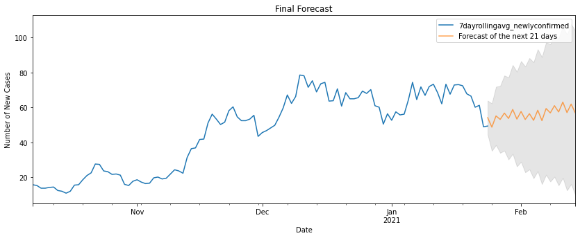

```
2021-01-24    54.176521
2021-01-25    48.759023
2021-01-26    55.170063
2021-01-27    53.179705
2021-01-28    56.797735
2021-01-29    53.722591
2021-01-30    58.864428
2021-01-31    53.363076
2021-02-01    57.711873
2021-02-02    53.149863
2021-02-03    56.437406
2021-02-04    52.668371
2021-02-05    58.410527
2021-02-06    52.480818
2021-02-07    59.402915
2021-02-08    56.902651
2021-02-09    61.029437
2021-02-10    57.446684
2021-02-11    63.094987
2021-02-12    57.088311
2021-02-13    61.941292
2021-02-14    56.876234
Freq: D, Name: predicted_mean, dtype: float64
```

```python
sarimax_model(Tehama)
```

## Riverside County

```
                                     SARIMAX Results
==========================================================================================
Dep. Variable:      7dayrollingavg_newlyconfirmed   No. Observations:                   92
Model:             SARIMAX(1, 1, 1)x(0, 1, 1, 12)   Log Likelihood                -211.589
Date:                            Fri, 29 Jan 2021   AIC                            431.179
Time:                                    17:43:56   BIC                            439.876
Sample:                                10-07-2020   HQIC                           434.611
                                     - 01-06-2021
Covariance Type:                              opg
==============================================================================
                 coef    std err          z      P>|z|      [0.025      0.975]
------------------------------------------------------------------------------
ar.L1          0.3533      0.268      1.317      0.188      -0.173       0.879
ma.L1          0.1555      0.285      0.546      0.585      -0.402       0.713
ma.S.L12      -1.0001    816.232     -0.001      0.999   -1600.785    1598.785
sigma2        31.0359   2.53e+04      0.001      0.999   -4.96e+04    4.97e+04
===================================================================================
Ljung-Box (L1) (Q):                   0.00   Jarque-Bera (JB):                82.86
Prob(Q):                              0.98   Prob(JB):                         0.00
Heteroskedasticity (H):              15.42   Skew:                            -0.70
Prob(H) (two-sided):                  0.00   Kurtosis:                         8.35
===================================================================================

Warnings:
[1] Covariance matrix calculated using the outer product of gradients (complex-step).
```

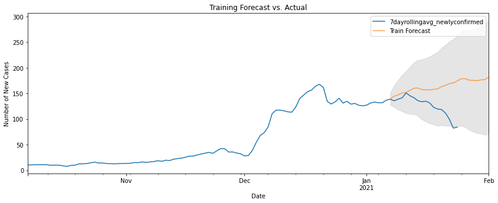

```
MSE of our forecasts is 1748.4
RMSE of our forecasts is 41.81
                                     SARIMAX Results
==========================================================================================
Dep. Variable:      7dayrollingavg_newlyconfirmed   No. Observations:                  110
Model:             SARIMAX(1, 1, 1)x(0, 1, 1, 12)   Log Likelihood                -272.340
Date:                            Fri, 29 Jan 2021   AIC                            552.679
Time:                                    17:44:05   BIC                            562.355
Sample:                                10-07-2020   HQIC                           556.566
                                     - 01-24-2021
Covariance Type:                              opg
==============================================================================
                 coef    std err          z      P>|z|      [0.025      0.975]
------------------------------------------------------------------------------
ar.L1          0.3847      0.241      1.595      0.111      -0.088       0.857
ma.L1          0.1313      0.272      0.483      0.629      -0.402       0.665
ma.S.L12      -1.0000   1359.002     -0.001      0.999   -2664.596    2662.596
sigma2        33.5125   4.55e+04      0.001      0.999   -8.92e+04    8.93e+04
===================================================================================
Ljung-Box (L1) (Q):                   0.00   Jarque-Bera (JB):                36.11
Prob(Q):                              0.98   Prob(JB):                         0.00
Heteroskedasticity (H):               7.63   Skew:                            -0.51
Prob(H) (two-sided):                  0.00   Kurtosis:                         6.06
===================================================================================

Warnings:
[1] Covariance matrix calculated using the outer product of gradients (complex-step).
```

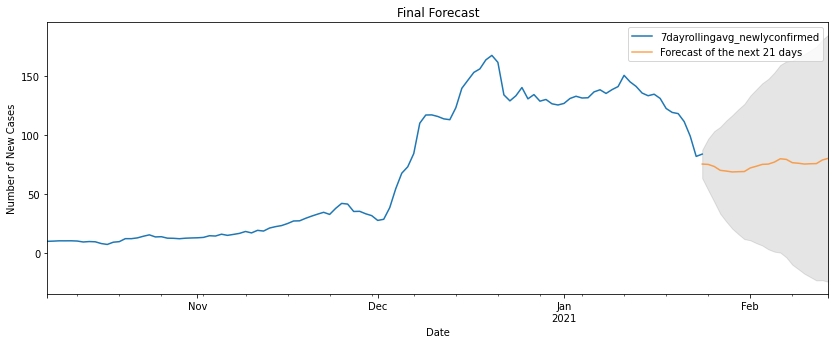

```
2021-01-24    75.762977
2021-01-25    75.461103
2021-01-26    73.724280
2021-01-27    70.465823
2021-01-28    69.825179
2021-01-29    69.081182
2021-01-30    69.290631
2021-01-31    69.418283
2021-02-01    72.469681
2021-02-02    73.902711
2021-02-03    75.493526
2021-02-04    75.740011
2021-02-05    77.406776
2021-02-06    80.241102
2021-02-07    79.710704
2021-02-08    76.916331
2021-02-09    76.454209
2021-02-10    75.778886
2021-02-11    76.014752
2021-02-12    76.152566
2021-02-13    79.207873
2021-02-14    80.642407
Freq: D, Name: predicted_mean, dtype: float64
```

```python
sarimax_model(Riverside)
```

## Colusa County

```
                                     SARIMAX Results
==========================================================================================
Dep. Variable:      7dayrollingavg_newlyconfirmed   No. Observations:                   92
Model:             SARIMAX(0, 1, 1)x(0, 1, 1, 12)   Log Likelihood                -238.917
Date:                            Fri, 29 Jan 2021   AIC                            483.834
Time:                                    17:44:11   BIC                            490.358
Sample:                                10-07-2020   HQIC                           486.408
                                     - 01-06-2021
Covariance Type:                              opg
==============================================================================
                 coef    std err          z      P>|z|      [0.025      0.975]
------------------------------------------------------------------------------
ma.L1          0.0896      0.169      0.531      0.596      -0.241       0.420
ma.S.L12      -1.0001    278.644     -0.004      0.997    -547.133     545.133
sigma2        71.9476   2.01e+04      0.004      0.997   -3.92e+04    3.94e+04
===================================================================================
Ljung-Box (L1) (Q):                   0.03   Jarque-Bera (JB):                94.64
Prob(Q):                              0.86   Prob(JB):                         0.00
Heteroskedasticity (H):               8.31   Skew:                            -0.95
Prob(H) (two-sided):                  0.00   Kurtosis:                         8.60
===================================================================================

Warnings:
[1] Covariance matrix calculated using the outer product of gradients (complex-step).
```

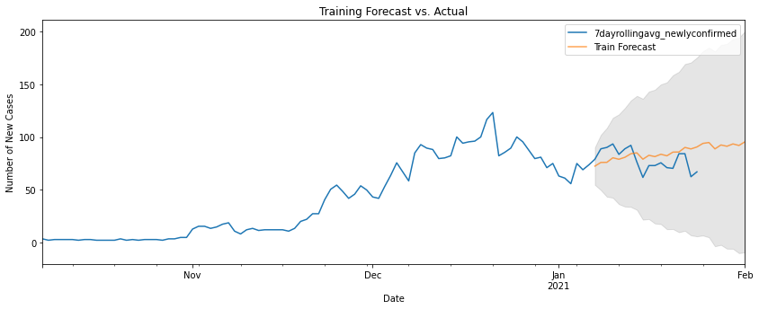

```
MSE of our forecasts is 166.79
RMSE of our forecasts is 12.91
                                     SARIMAX Results
==========================================================================================
Dep. Variable:      7dayrollingavg_newlyconfirmed   No. Observations:                  110
Model:             SARIMAX(0, 1, 1)x(0, 1, 1, 12)   Log Likelihood                -302.065
Date:                            Fri, 29 Jan 2021   AIC                            610.129
Time:                                    17:44:18   BIC                            617.386
Sample:                                10-07-2020   HQIC                           613.045
                                     - 01-24-2021
Covariance Type:                              opg
==============================================================================
                 coef    std err          z      P>|z|      [0.025      0.975]
------------------------------------------------------------------------------
ma.L1          0.1529      0.139      1.103      0.270      -0.119       0.425
ma.S.L12      -0.7847      0.127     -6.181      0.000      -1.033      -0.536
sigma2        79.5408      7.602     10.463      0.000      64.640      94.441
===================================================================================
Ljung-Box (L1) (Q):                   0.15   Jarque-Bera (JB):                92.42
Prob(Q):                              0.70   Prob(JB):                         0.00
Heteroskedasticity (H):               3.58   Skew:                            -0.87
Prob(H) (two-sided):                  0.00   Kurtosis:                         7.87
===================================================================================

Warnings:
[1] Covariance matrix calculated using the outer product of gradients (complex-step).
```

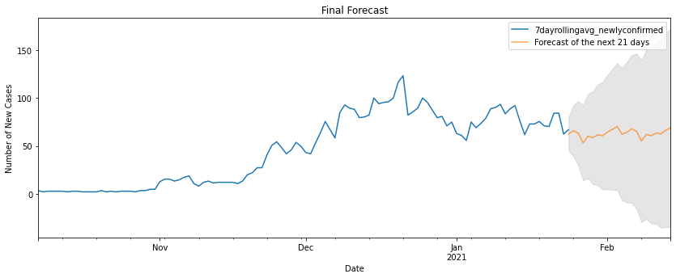

```
2021-01-24    62.361638
2021-01-25    65.894395
2021-01-26    63.272502
2021-01-27    53.173751
2021-01-28    60.120858
2021-01-29    58.634206
2021-01-30    61.620907
2021-01-31    60.564054
2021-02-01    64.377488
2021-02-02    67.148564
2021-02-03    70.347904
2021-02-04    62.272947
2021-02-05    64.306203
2021-02-06    67.838960
2021-02-07    65.217067
2021-02-08    55.118316
2021-02-09    62.065422
2021-02-10    60.578771
2021-02-11    63.565472
2021-02-12    62.508619
2021-02-13    66.322053
2021-02-14    69.093129
Freq: D, Name: predicted_mean, dtype: float64
```

```python
sarimax_model(Colusa)
```

## Merced County

```
                                     SARIMAX Results
==========================================================================================
Dep. Variable:      7dayrollingavg_newlyconfirmed   No. Observations:                   92
Model:             SARIMAX(0, 1, 1)x(0, 1, 1, 12)   Log Likelihood                -194.556
Date:                            Fri, 29 Jan 2021   AIC                            395.113
Time:                                    17:44:25   BIC                            401.636
Sample:                                10-07-2020   HQIC                           397.687
                                     - 01-06-2021
Covariance Type:                              opg
==============================================================================
                 coef    std err          z      P>|z|      [0.025      0.975]
------------------------------------------------------------------------------
ma.L1          0.1548      0.153      1.014      0.311      -0.144       0.454
ma.S.L12      -1.0001    675.280     -0.001      0.999   -1324.525    1322.525
sigma2        18.3758   1.24e+04      0.001      0.999   -2.43e+04    2.43e+04
===================================================================================
Ljung-Box (L1) (Q):                   0.02   Jarque-Bera (JB):               102.65
Prob(Q):                              0.88   Prob(JB):                         0.00
Heteroskedasticity (H):               8.48   Skew:                             0.74
Prob(H) (two-sided):                  0.00   Kurtosis:                         8.98
===================================================================================

Warnings:
[1] Covariance matrix calculated using the outer product of gradients (complex-step).
```

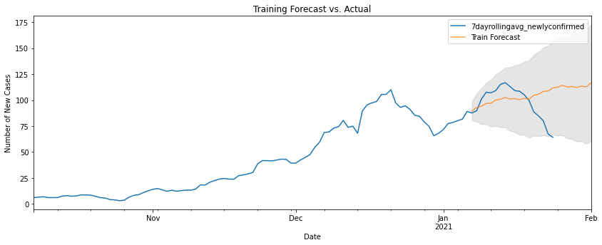

```
MSE of our forecasts is 363.26
RMSE of our forecasts is 19.06
                                     SARIMAX Results
==========================================================================================
Dep. Variable:      7dayrollingavg_newlyconfirmed   No. Observations:                  110
Model:             SARIMAX(1, 1, 1)x(0, 1, 1, 12)   Log Likelihood                -249.180
Date:                            Fri, 29 Jan 2021   AIC                            506.359
Time:                                    17:44:32   BIC                            516.035
Sample:                                10-07-2020   HQIC                           510.246
                                     - 01-24-2021
Covariance Type:                              opg
==============================================================================
                 coef    std err          z      P>|z|      [0.025      0.975]
------------------------------------------------------------------------------
ar.L1          0.8383      0.152      5.500      0.000       0.540       1.137
ma.L1         -0.5791      0.213     -2.717      0.007      -0.997      -0.161
ma.S.L12      -0.9193      0.368     -2.497      0.013      -1.641      -0.198
sigma2        20.5924      6.280      3.279      0.001       8.283      32.901
===================================================================================
Ljung-Box (L1) (Q):                   0.05   Jarque-Bera (JB):               120.34
Prob(Q):                              0.83   Prob(JB):                         0.00
Heteroskedasticity (H):               7.65   Skew:                             0.85
Prob(H) (two-sided):                  0.00   Kurtosis:                         8.65
===================================================================================

Warnings:
[1] Covariance matrix calculated using the outer product of gradients (complex-step).
```

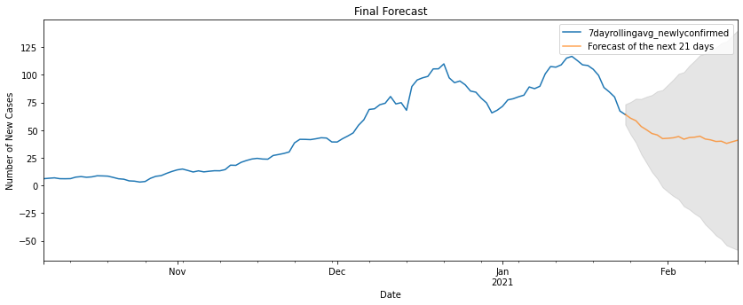

```
2021-01-24    64.285869
2021-01-25    60.837341
2021-01-26    58.572445
2021-01-27    53.333272
2021-01-28    50.333978
2021-01-29    47.010946
2021-01-30    45.696971
2021-01-31    42.371550
2021-02-01    42.690658
2021-02-02    43.111861
2021-02-03    44.278565
2021-02-04    41.852276
2021-02-05    43.319532
2021-02-06    43.664348
2021-02-07    44.579376
2021-02-08    42.005906
2021-02-09    41.241245
2021-02-10    39.791486
2021-02-11    40.047859
2021-02-12    38.038846
2021-02-13    39.461486
2021-02-14    40.807770
Freq: D, Name: predicted_mean, dtype: float64
```

```python
sarimax_model(Merced)
```

## Santa Barbara County

```
                                     SARIMAX Results
==========================================================================================
Dep. Variable:      7dayrollingavg_newlyconfirmed   No. Observations:                   92
Model:             SARIMAX(1, 0, 1)x(1, 1, 1, 12)   Log Likelihood                -153.615
Date:                            Fri, 29 Jan 2021   AIC                            317.229
Time:                                    17:44:39   BIC                            328.178
Sample:                                10-07-2020   HQIC                           321.555
                                     - 01-06-2021
Covariance Type:                              opg
==============================================================================
                 coef    std err          z      P>|z|      [0.025      0.975]
------------------------------------------------------------------------------
ar.L1          1.0377      0.006    170.018      0.000       1.026       1.050
ma.L1         -0.3058      0.118     -2.588      0.010      -0.537      -0.074
ar.S.L12      -0.1942      0.193     -1.005      0.315      -0.573       0.184
ma.S.L12      -0.8933      0.638     -1.400      0.162      -2.144       0.357
sigma2         4.8662      2.706      1.798      0.072      -0.437      10.169
===================================================================================
Ljung-Box (L1) (Q):                   0.30   Jarque-Bera (JB):                 3.35
Prob(Q):                              0.58   Prob(JB):                         0.19
Heteroskedasticity (H):              17.00   Skew:                            -0.43
Prob(H) (two-sided):                  0.00   Kurtosis:                         3.69
===================================================================================

Warnings:
[1] Covariance matrix calculated using the outer product of gradients (complex-step).
```

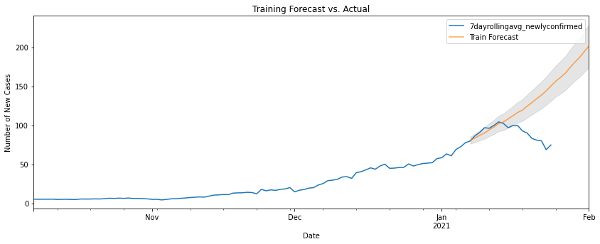

```
MSE of our forecasts is 1241.03
RMSE of our forecasts is 35.23
                                     SARIMAX Results
==========================================================================================
Dep. Variable:      7dayrollingavg_newlyconfirmed   No. Observations:                  110
Model:             SARIMAX(1, 1, 1)x(0, 1, 1, 12)   Log Likelihood                -213.970
Date:                            Fri, 29 Jan 2021   AIC                            435.939
Time:                                    17:44:45   BIC                            445.614
Sample:                                10-07-2020   HQIC                           439.826
                                     - 01-24-2021
Covariance Type:                              opg
==============================================================================
                 coef    std err          z      P>|z|      [0.025      0.975]
------------------------------------------------------------------------------
ar.L1          0.8926      0.120      7.429      0.000       0.657       1.128
ma.L1         -1.4277      0.375     -3.808      0.000      -2.163      -0.693
ma.S.L12      -0.6716      0.090     -7.437      0.000      -0.849      -0.495
sigma2         4.8260      2.589      1.864      0.062      -0.249       9.901
===================================================================================
Ljung-Box (L1) (Q):                   5.90   Jarque-Bera (JB):                 5.06
Prob(Q):                              0.02   Prob(JB):                         0.08
Heteroskedasticity (H):               7.96   Skew:                            -0.33
Prob(H) (two-sided):                  0.00   Kurtosis:                         4.01
===================================================================================

Warnings:
[1] Covariance matrix calculated using the outer product of gradients (complex-step).
```

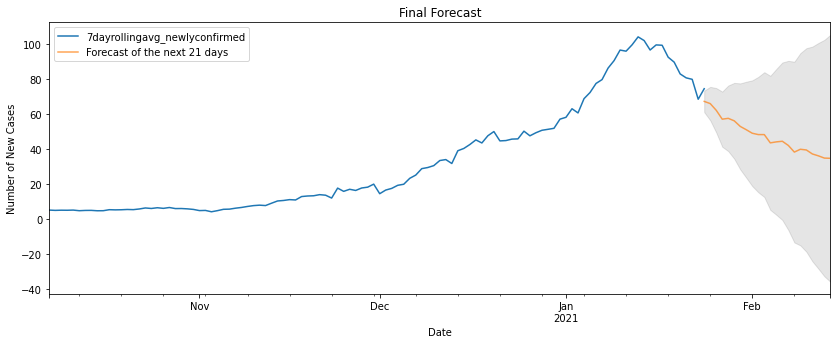

```
2021-01-24    67.421419
2021-01-25    66.170185
2021-01-26    62.337484
2021-01-27    57.254327
2021-01-28    57.729262
2021-01-29    56.302347
2021-01-30    53.105415
2021-01-31    51.218468
2021-02-01    49.204549
2021-02-02    48.435371
2021-02-03    48.428153
2021-02-04    43.700187
2021-02-05    44.263314
2021-02-06    44.621307
2021-02-07    42.224986
2021-02-08    38.423926
2021-02-09    40.043247
2021-02-10    39.637799
2021-02-11    37.352617
2021-02-12    36.279488
2021-02-13    34.991976
2021-02-14    34.871180
Freq: D, Name: predicted_mean, dtype: float64
```

```python
sarimax_model(Santa_Barbara)
```

## Inyo County

```
                                     SARIMAX Results
==========================================================================================
Dep. Variable:      7dayrollingavg_newlyconfirmed   No. Observations:                   92
Model:             SARIMAX(0, 1, 1)x(0, 1, 1, 12)   Log Likelihood                -226.148
Date:                            Fri, 29 Jan 2021   AIC                            458.297
Time:                                    17:44:50   BIC                            464.820
Sample:                                10-07-2020   HQIC                           460.871
                                     - 01-06-2021
Covariance Type:                              opg
==============================================================================
                 coef    std err          z      P>|z|      [0.025      0.975]
------------------------------------------------------------------------------
ma.L1         -0.2127      0.117     -1.818      0.069      -0.442       0.017
ma.S.L12      -1.0000   7702.925     -0.000      1.000   -1.51e+04    1.51e+04
sigma2        48.5770   3.74e+05      0.000      1.000   -7.33e+05    7.33e+05
===================================================================================
Ljung-Box (L1) (Q):                   0.05   Jarque-Bera (JB):                39.69
Prob(Q):                              0.82   Prob(JB):                         0.00
Heteroskedasticity (H):               7.09   Skew:                            -0.76
Prob(H) (two-sided):                  0.00   Kurtosis:                         6.51
===================================================================================

Warnings:
[1] Covariance matrix calculated using the outer product of gradients (complex-step).
```

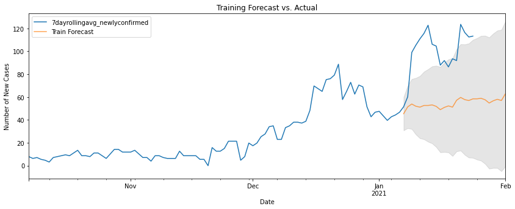

```
MSE of our forecasts is 2443.37
RMSE of our forecasts is 49.43
                                     SARIMAX Results
==========================================================================================
Dep. Variable:      7dayrollingavg_newlyconfirmed   No. Observations:                  110
Model:             SARIMAX(0, 1, 1)x(1, 1, 1, 12)   Log Likelihood                -299.618
Date:                            Fri, 29 Jan 2021   AIC                            607.235
Time:                                    17:44:57   BIC                            616.911
Sample:                                10-07-2020   HQIC                           611.122
                                     - 01-24-2021
Covariance Type:                              opg
==============================================================================
                 coef    std err          z      P>|z|      [0.025      0.975]
------------------------------------------------------------------------------
ma.L1         -0.1234      0.106     -1.166      0.243      -0.331       0.084
ar.S.L12      -0.4009      0.122     -3.281      0.001      -0.640      -0.161
ma.S.L12      -0.4265      0.148     -2.875      0.004      -0.717      -0.136
sigma2        78.0135      8.978      8.690      0.000      60.417      95.610
===================================================================================
Ljung-Box (L1) (Q):                   0.01   Jarque-Bera (JB):                22.12
Prob(Q):                              0.94   Prob(JB):                         0.00
Heteroskedasticity (H):               3.32   Skew:                            -0.12
Prob(H) (two-sided):                  0.00   Kurtosis:                         5.52
===================================================================================

Warnings:
[1] Covariance matrix calculated using the outer product of gradients (complex-step).
```

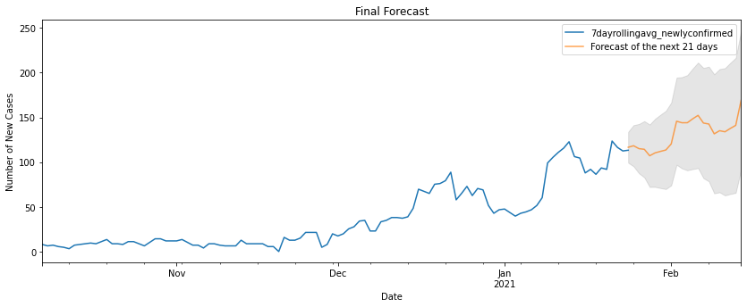

```
2021-01-24    116.546752
2021-01-25    118.262045
2021-01-26    115.016241
2021-01-27    114.299321
2021-01-28    107.070333
2021-01-29    110.308255
2021-01-30    111.951226
2021-01-31    113.504049
2021-02-01    120.246774
2021-02-02    145.685588
2021-02-03    143.957771
2021-02-04    144.006428
2021-02-05    148.354667
2021-02-06    152.239934
2021-02-07    143.627524
2021-02-08    142.563003
2021-02-09    131.564454
2021-02-10    135.091761
2021-02-11    133.853321
2021-02-12    137.641259
2021-02-13    141.045462
2021-02-14    168.985616
Freq: D, Name: predicted_mean, dtype: float64
```

```python
sarimax_model(Inyo)
```

## Tulare County

```
                                     SARIMAX Results
==========================================================================================
Dep. Variable:      7dayrollingavg_newlyconfirmed   No. Observations:                   92
Model:             SARIMAX(0, 1, 1)x(0, 1, 1, 12)   Log Likelihood                -196.813
Date:                            Fri, 29 Jan 2021   AIC                            399.627
Time:                                    17:45:04   BIC                            406.150
Sample:                                10-07-2020   HQIC                           402.201
                                     - 01-06-2021
Covariance Type:                              opg
==============================================================================
                 coef    std err          z      P>|z|      [0.025      0.975]
------------------------------------------------------------------------------
ma.L1          0.4319      0.149      2.893      0.004       0.139       0.724
ma.S.L12      -1.0000    832.652     -0.001      0.999   -1632.969    1630.969
sigma2        19.6950   1.64e+04      0.001      0.999   -3.21e+04    3.22e+04
===================================================================================
Ljung-Box (L1) (Q):                   0.19   Jarque-Bera (JB):               297.76
Prob(Q):                              0.66   Prob(JB):                         0.00
Heteroskedasticity (H):              10.38   Skew:                            -1.86
Prob(H) (two-sided):                  0.00   Kurtosis:                        12.80
===================================================================================

Warnings:
[1] Covariance matrix calculated using the outer product of gradients (complex-step).
```

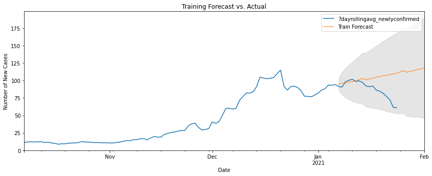

```
MSE of our forecasts is 491.05
RMSE of our forecasts is 22.16
                                     SARIMAX Results
==========================================================================================
Dep. Variable:      7dayrollingavg_newlyconfirmed   No. Observations:                  110
Model:             SARIMAX(0, 1, 1)x(0, 1, 1, 12)   Log Likelihood                -249.866
Date:                            Fri, 29 Jan 2021   AIC                            505.732
Time:                                    17:45:12   BIC                            512.989
Sample:                                10-07-2020   HQIC                           508.647
                                     - 01-24-2021
Covariance Type:                              opg
==============================================================================
                 coef    std err          z      P>|z|      [0.025      0.975]
------------------------------------------------------------------------------
ma.L1          0.3791      0.142      2.663      0.008       0.100       0.658
ma.S.L12      -1.0000   2976.328     -0.000      1.000   -5834.495    5832.495
sigma2        19.4990    5.8e+04      0.000      1.000   -1.14e+05    1.14e+05
===================================================================================
Ljung-Box (L1) (Q):                   0.00   Jarque-Bera (JB):               192.85
Prob(Q):                              0.95   Prob(JB):                         0.00
Heteroskedasticity (H):               4.01   Skew:                            -1.33
Prob(H) (two-sided):                  0.00   Kurtosis:                         9.98
===================================================================================

Warnings:
[1] Covariance matrix calculated using the outer product of gradients (complex-step).
```

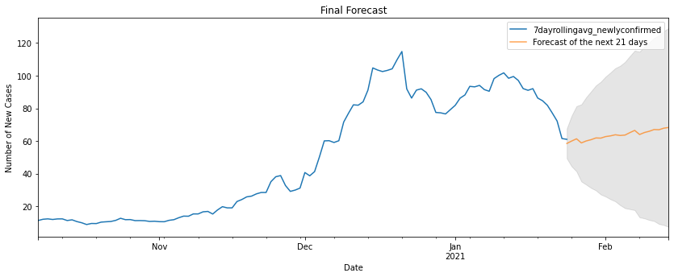

```
2021-01-24    58.443416
2021-01-25    59.938121
2021-01-26    61.303446
2021-01-27    58.783894
2021-01-28    59.996003
2021-01-29    60.768891
2021-01-30    61.831188
2021-01-31    61.718829
2021-02-01    62.668767
2021-02-02    63.097771
2021-02-03    63.782139
2021-02-04    63.342931
2021-02-05    63.599490
2021-02-06    65.094195
2021-02-07    66.459520
2021-02-08    63.939968
2021-02-09    65.152077
2021-02-10    65.924965
2021-02-11    66.987262
2021-02-12    66.874903
2021-02-13    67.824841
2021-02-14    68.253845
Freq: D, Name: predicted_mean, dtype: float64
```

```python
sarimax_model(Tulare)
```